# Q3 statistic

Chun Hsien Wu

2021年10月18日

### Q3 統計量的內涵與程式實現

俊賢寫的內容

局部獨立性是單向度試題反應理論的基本假設之一（另一假設為單向度）

局部獨立性是指潛在能力控制的條件下受測者在回答一個試題的作答反應機率與回答另一個試題的反應機率無關

Q3統計量是Yen(1983)所提出 目的是考驗 檢測在試題反應模式下 兩兩試題間殘差分數的相關

Q3 統計量的公式如下

受試者n 在試題i上的得分殘差為
$$d_{ni} = u_{ni} - \rm E_i(\hat \theta_{ni})$$

受試者n 在試題j上的得分殘差為

$$d_{nk} = u_{nk} - \rm E_k(\hat \theta_{nk})$$
Q3統計量為受試者n 在試題i 和試題k 上殘差得分的相關
$$Q3_{ij}= \gamma_{didk}$$

$u_{ni}$表示受試者$n$在第$i$ 題的得分 代表真實分數

$\rm E_i(\hat \theta_n)$ 為受試者$n$ 在第$i$ 題上的期望分數

#### 文獻

(from Okan Bulut)(page 113) When the assumption of unidimensional holds, the local independence assumpton is also met because the two concepts are related to each other only through the single latent trait (Lord, 1980). Yen’s Q3 statistic (Yen, 1984) is one of the most commonly used methods for checking the local independence assumption.

吳宛諭(多向度隨機閾值試題反應理論模式的發展與應用) 使用Q3統計(Yen, 1983)作為模式差異測量 考驗模式的絕對適配度

(Embretson book Item Response Theory for psychologists page 188) Local independence means that the response to any item is unrelated to any other item when trait level is controlled. The items may be highly intercorrelated in the whole sample; however, if trait level is controlled, local independence implies that no relationships remain between the items.

(de Ayala book page 133)

If $|Q_3|$ equals 1.0, then the two items are perfectly dependent. In constrast, a $|Q_3|$ of 0.0 is a necessary, but not sufficient condition for inCoverdependence because a $Q_3 = 0$ can be obtained when the items in pair are independ of one another or be cause they exhibit a nonlinear relationship. Therefore, $Q_3$ is useful for identifying items that exhibit item dependence. Under conditional independence $Q_3$ should have an expected value of $-1 \above 1pt (L-1)$ (Yen, 1993)

#### using sirt package mod.q3 function to calculate Q3 statistic

```r
library("sirt")
data(data.read)
```

```r
#Estimate the Rasch model
mod <- sirt::rasch.mml2( data.read)
```

[output not shown]

[output cut: 35 more lines]

[output not shown]

```r
# estmate WLEs
mod.wle <- sirt::wle.rasch( dat=data.read, b=mod$item$b )
```

```
##
## WLE Reliability= 0.567
```

```r
# calculate Yen's Q3 statistic
mod.q3 <- sirt::Q3( dat=data.read, theta=mod.wle$theta, b=mod$item$b )
```

```
## Yen's Q3 Statistic based on an estimated theta score
## *** 12 Items | 66 item pairs
## *** Q3 Descriptives
##      M     SD    Min    10%    25%    50%    75%    90%    Max
## -0.085  0.110 -0.261 -0.194 -0.152 -0.107 -0.051  0.041  0.412
```

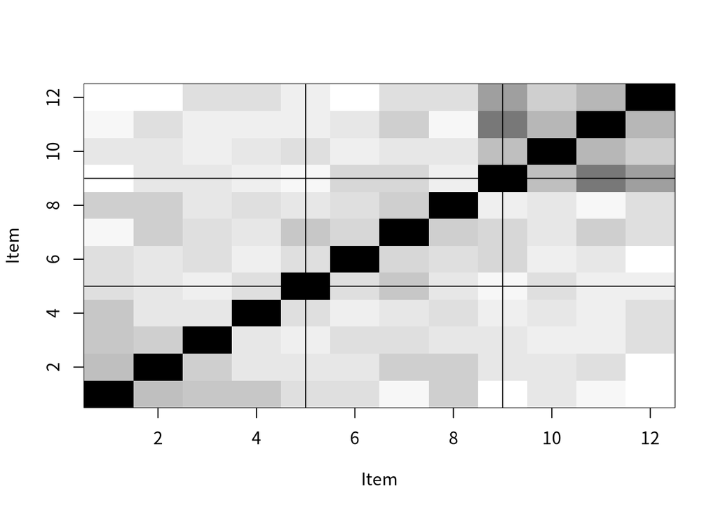

```r
# plot Q3 statistics
I <- ncol(data.read)
image( 1:I, 1:I, mod.q3$q3.matrix, col=gray( 1 - (0:32)/32),
        xlab="Item", ylab="Item")
abline(v=c(5,9)) # borders for testlets
abline(h=c(5,9))
```

To check the result of q3.mod, first to check the name of mod.q3

```r
names(mod.q3)
```

```
## [1] "q3.matrix" "q3.long"   "expected"  "residual"  "Q3.stat"
```

```r
mod.q3$q3.matrix
```

```
##               A1           A2           A3          A4          B1          B2
## A1  1.0000000000  0.059615249  0.022709438  0.04205432 -0.08797109 -0.07043897
## A2  0.0596152491  1.000000000 -0.004881878 -0.12930498 -0.12998652 -0.13609823
## A3  0.0227094375 -0.004881878  1.000000000 -0.11511331 -0.16315935 -0.07114410
## A4  0.0420543236 -0.129304981 -0.115113306  1.00000000 -0.08068968 -0.15047495
## B1 -0.0879710913 -0.129986521 -0.163159346 -0.08068968  1.00000000 -0.07557294
## B2 -0.0704389691 -0.136098227 -0.071144100 -0.15047495 -0.07557294  1.00000000
## B3 -0.2063235201  0.001161297 -0.086307128 -0.12101096  0.03911790 -0.04969534
## B4 -0.0008937428  0.002316076 -0.123570889 -0.10426424 -0.10842113 -0.10658299
## C1 -0.2607454333 -0.108978088 -0.145225489 -0.15348418 -0.19646114 -0.05431140
## C2 -0.1195743487 -0.140031341 -0.174879628 -0.13010810 -0.08236444 -0.16378145
## C3 -0.1910514021 -0.098453366 -0.162570812 -0.16046031 -0.16851236 -0.12515509
## C4 -0.2339723388 -0.241848986 -0.094756000 -0.07995784 -0.15187230 -0.22733278
##              B3            B4          C1           C2          C3           C4
## A1 -0.206323520 -0.0008937428 -0.26074543 -0.119574349 -0.19105140 -0.233972339
## A2  0.001161297  0.0023160756 -0.10897809 -0.140031341 -0.09845337 -0.241848986
## A3 -0.086307128 -0.1235708889 -0.14522549 -0.174879628 -0.16257081 -0.094756000
## A4 -0.121010958 -0.1042642401 -0.15348418 -0.130108099 -0.16046031 -0.079957839
## B1  0.039117898 -0.1084211278 -0.19646114 -0.082364437 -0.16851236 -0.151872298
## B2 -0.049695343 -0.1065829908 -0.05431140 -0.163781453 -0.12515509 -0.227332785
## B3  1.000000000 -0.0300933435 -0.06422386 -0.108269979 -0.01021053 -0.080370889
## B4 -0.030093343  1.0000000000 -0.15724883 -0.139448037 -0.21397712 -0.102900041
## C1 -0.064223860 -0.1572488309  1.00000000  0.071141959  0.41156097  0.225568570
## C2 -0.108269979 -0.1394480371  0.07114196  1.000000000  0.10197263  0.001039757
## C3 -0.010210534 -0.2139771150  0.41156097  0.101972630  1.00000000  0.085910119
## C4 -0.080370889 -0.1029000410  0.22556857  0.001039757  0.08591012  1.000000000
```

We can understand q3.matrix is 12 by 12 matrix. It’s the Q3 statistic.